# Fires in the Paraná River Delta

Natalia Morandeira

8/7/2020, updated 3/22/2021

## Input the spatial objects to R

### Data source

- Paraná River Delta limits: shapefile of the study area. Save this vector in the path */data/study_area/*
- Hotspots from FIRMS-NASA, https://firms.modaps.eosdis.nasa.gov/map/#t:adv;d:2020-07-28..2020-08-03;@-59.9,-33.1,8z . Save the downloaded zip files in the path */data/zip/*

### Naming conventions of the FIRMS data:

- DL_FIRE_M6.xx if you requested MODIS data (M6 stands for MODIS Collection 6), or
- DL_FIRE_V1.xx if you requested VIIRS 375m data from S-NPP
- DL_FIRE_J1.xx if you requested VIIRS 375m data from NOAA-20 (JPSS-1). *For quick analyses, I usually don’t request these data because hotspots may be redundant with VIIRS S-NPP.*

### Spatial data pre-processing

1. Read files and unzip
2. Handle the files as spatial data
3. Merge
4. Re-project
5. Clip by study area

To read and unzip, we first set the names of the two ZIP files, one from MODIS and the other from VIIRS satellites. Each of these zips has two shapefiles: recent and archive records.

```r
zipfiles <- list.files(path = "data/zip/")
zipfiles
```

```
## [1] "DL_FIRE_M6_189060.zip" "DL_FIRE_V1_189061.zip"
```

We unzip the data.

```r
MODISzip <- paste("data/zip/", zipfiles[1], sep="")
VIIRSzip <- paste("data/zip/", zipfiles[2], sep="")

unzip(MODISzip, exdir = "data/hotspots/")
unzip(VIIRSzip, exdir = "data/hotspots/")
```

There are 2 zip files in the database (expected: two files).

Handle spatial data. Four shapefiles + Study area. The code is prepared to detect the appropriate strings and generate the spatial objects, based on the naming conventions of FIRMS-NASA.

```r
library(sf)
library(stringr)
spatial_files <- list.files(path = "data/hotspots")
shp_extension <- str_detect(spatial_files, "shp")=="TRUE"
spatial_files <- subset(spatial_files, shp_extension == "TRUE")

hotspots_VIIRS_recent <- which(str_detect(spatial_files, "fire_nrt_V1")=="TRUE")
hotspots_VIIRS_recent <- paste("data/hotspots/", spatial_files[hotspots_VIIRS_recent], sep="")
hotspots_VIIRS_recent <- st_read(hotspots_VIIRS_recent, quiet=TRUE)

hotspots_VIIRS_archive <- which(str_detect(spatial_files, "fire_archive_V1")=="TRUE")
hotspots_VIIRS_archive <- paste("data/hotspots/", spatial_files[hotspots_VIIRS_archive], sep="")
hotspots_VIIRS_archive <- st_read(hotspots_VIIRS_archive, quiet=TRUE)

hotspots_MODIS_recent <- which(str_detect(spatial_files, "fire_nrt_M6")=="TRUE")
hotspots_MODIS_recent <- paste("data/hotspots/", spatial_files[hotspots_MODIS_recent], sep="")
hotspots_MODIS_recent <- st_read(hotspots_MODIS_recent, quiet=TRUE)

hotspots_MODIS_archive <- which(str_detect(spatial_files, "fire_archive_M6")=="TRUE")
hotspots_MODIS_archive <- paste("data/hotspots/", spatial_files[hotspots_MODIS_archive], sep="")
hotspots_MODIS_archive <- st_read(hotspots_MODIS_archive, quiet=TRUE)

study_area <- list.files(path = "data/study_area/")
study_area_shp <- str_detect(study_area, "shp")=="TRUE"
study_area <- subset(study_area, study_area_shp == "TRUE")
study_area <- paste("data/study_area/", study_area, sep="")
study_area <- st_read(study_area, quiet=TRUE)
```

Merge the hotspot data.

```r
#Remove CONFIDENCE columns since they have different formats
hotspots_VIIRS_recent$CONFIDENCE = NULL
hotspots_VIIRS_archive$CONFIDENCE = NULL
hotspots_VIIRS_archive$TYPE = NULL

hotspots_MODIS_recent$CONFIDENCE = NULL
hotspots_MODIS_archive$CONFIDENCE = NULL
hotspots_MODIS_archive$TYPE = NULL

#Merge
hotspots_v <- rbind(hotspots_VIIRS_recent,hotspots_VIIRS_archive)
hotspots_m <- rbind(hotspots_MODIS_recent, hotspots_MODIS_archive)
colnames(hotspots_v) <- colnames(hotspots_m)
hotspots_all <- rbind(hotspots_v, hotspots_m)
```

Now we need to reproject the hotspot data to the same CRS than the study area.

```r
library(sf)
study_area_crs <- st_crs(study_area)
#study_area_epsg <- study_area_crs$epsg #check, is not working
study_area_epsg <- 5347
study_area <- st_transform(study_area, study_area_epsg)

#reproject
hotspots_all <- st_transform(hotspots_all, study_area_epsg)
```

Lastly, we clip the hotspots by the study area.

```r
hotspots_studyarea <- st_intersects(x=hotspots_all, y=study_area)
hotspots_studyarea_logical <- lengths(hotspots_studyarea) > 0

hotspots_all = hotspots_all[hotspots_studyarea_logical, ]
```

### *Importing a pre-processed hotspot layer as spatial object*

Alternatively, the script can also begin with a pre-processed final hotspot layer.

```r
library(sf)
hotspots_all <- st_read("data/hotspots/focos_all_20201110.shp", quiet=TRUE)
study_area <- st_read(dsn = "data/study_area/Delta_BajoParana_EPSG5347.shp", quiet=TRUE)
```

## Data processing

This layer has both MODIS and VIIRS hotspots. Extract VIIRS 2020 data.

```r
library(tidyverse)
library(spdplyr) # required to run dplyr funcions on spatial objects
hotspots_VIIRS_2020 <- hotspots_all %>%
  mutate(year = format(ACQ_DATE, "%Y")) %>%
  filter(year == "2020") %>%
  filter(INSTRUMENT == "VIIRS")

last_date <- max(hotspots_VIIRS_2020$ACQ_DATE)

hotspots_count2020 <- as.numeric(nrow(hotspots_VIIRS_2020)) # Total hotspots in 2020
```

The number of VIIRS hotspots recorded during this year is **3.982110^{4}**, up to **2020-12-31**.

Let’s get a quick interactive map to visualize the location of the hotspot records. The date of the record can be obtained by positioning the mouse onto the point.

```r
library(tmap)
tmap_mode("view")
mapa <- tm_shape(hotspots_VIIRS_2020,  bbox= study_area) +
  tm_dots(col = "red", alpha = 0.3, id="ACQ_DATE") +
  tm_layout(title = "Focos de incendio en el Bajo Paraná - 2020, Datos VIIRS", legend.frame = T) +
  tm_shape(study_area) +
  tm_borders(col = "grey60", lwd = 2)

mapa
```

We need to generate cummulative number of hotspot records during 2020.

```r
library(janitor)
focos2020 <- hotspots_VIIRS_2020
st_geometry(focos2020) <- NULL #quitar geometría
focos2020 <- clean_names(focos2020)
colnames(focos2020)
```

```
##  [1] "latitude"   "longitude"  "brightness" "scan"       "track"
##  [6] "acq_date"   "acq_time"   "satellite"  "instrument" "version"
## [11] "bright_t31" "frp"        "daynight"   "year"
```

```r
focos_cum <- focos2020 %>%
  mutate(cantidad = 1) %>%
  group_by(acq_date) %>%
  summarize(cantidad_diaria = sum(cantidad))
focos_cum$acumulado <- cumsum(focos_cum$cantidad_diaria)
head(focos_cum)
```

```
## # A tibble: 6 x 3
##   acq_date   cantidad_diaria acumulado
##   <date>               <dbl>     <dbl>
## 1 2020-01-01               1         1
## 2 2020-01-03               3         4
## 3 2020-01-04               3         7
## 4 2020-01-05               2         9
## 5 2020-01-08              12        21
## 6 2020-01-09               2        23
```

First, we’ll get a plot of the daily records. Spanish and English versions

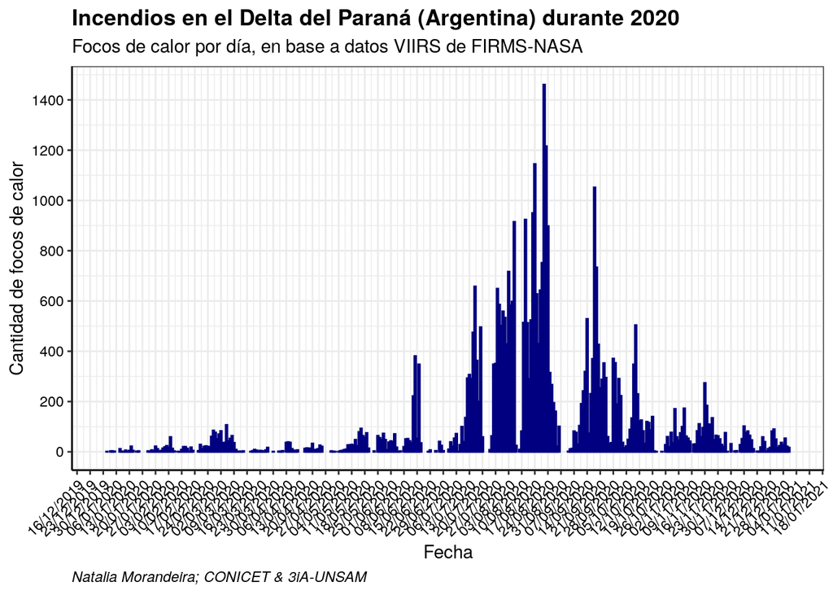

```r
#Spanish
plot_diario <- focos_cum %>%
  pivot_longer(names_to = "focos", values_to = "cantidad", col=cantidad_diaria:acumulado) %>%
  filter(focos == "cantidad_diaria") %>%
  ggplot(aes (x=acq_date, y=cantidad, color=focos)) +
  geom_col() +
  scale_color_manual(values=c("navyblue", "navyblue"),  labels = c("Focos diarios", "Nuevos focos")) +
  xlab("Fecha") +
  ylab("Cantidad de focos de calor") +
  scale_x_date(date_labels = "%d/%m/%Y", breaks = "week") +
  scale_y_continuous(breaks=seq(from = 0, to = 3000, by = 200)) +
  theme_bw()+
  theme(axis.text.x = element_text(angle=45, hjust=1, color="black"), plot.caption = element_text(hjust = 0, vjust=1, face = "italic"), plot.title = element_text(face = "bold"), axis.line=element_line(color="black"), axis.text.y=element_text(color="black"), legend.position = "none" ) +
  labs(title="Incendios en el Delta del Paraná (Argentina) durante 2020", subtitle = "Focos de calor por día, en base a datos VIIRS de FIRMS-NASA", caption = "Natalia Morandeira; CONICET & 3iA-UNSAM")

plot_diario
```

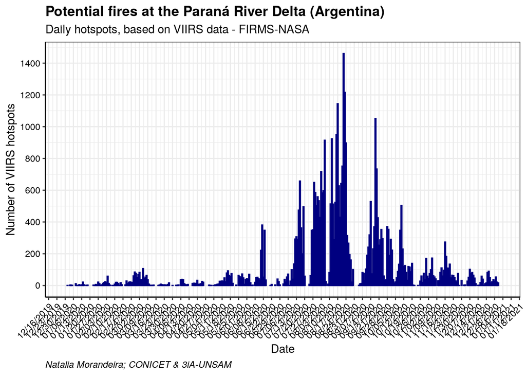

```r
plot_daily_eng <- focos_cum %>%
  pivot_longer(names_to = "focos", values_to = "cantidad", col=cantidad_diaria:acumulado) %>%
  filter(focos == "cantidad_diaria") %>%
  ggplot(aes (x=acq_date, y=cantidad, color=focos)) +
  geom_col() +
  scale_color_manual(values=c("navyblue", "navyblue"),  labels = c("New hotspots", "New hotspots")) +
  xlab("Date") +
  ylab("Number of VIIRS hotspots") +
  scale_x_date(date_labels = "%m/%d/%Y", breaks = "week") +
  scale_y_continuous(breaks=seq(from = 0, to = 3000, by = 200)) +
  theme_bw()+
  theme(axis.text.x = element_text(angle=45, hjust=1, color="black"), plot.caption = element_text(hjust = 0, vjust=1, face = "italic"), plot.title = element_text(face = "bold"), legend.position="none", axis.line=element_line(color="black"), axis.text.y=element_text(color="black")) +
  labs(title="Potential fires at the Paraná River Delta (Argentina)", subtitle = "Daily hotspots, based on VIIRS data - FIRMS-NASA", caption = "Natalia Morandeira; CONICET & 3iA-UNSAM")

plot_daily_eng
```

We may export these plots.

```r
ggsave("output/Focos_diario_2020-12-31.png", plot = plot_diario, width = 9, height = 5, dpi = 300)
ggsave("output/Hotspot_daily_2020-12-31.png", plot = plot_daily_eng, width = 9, height = 5, dpi = 300)
```

A plot of the cummulative hostspots. Spanish and English versions.

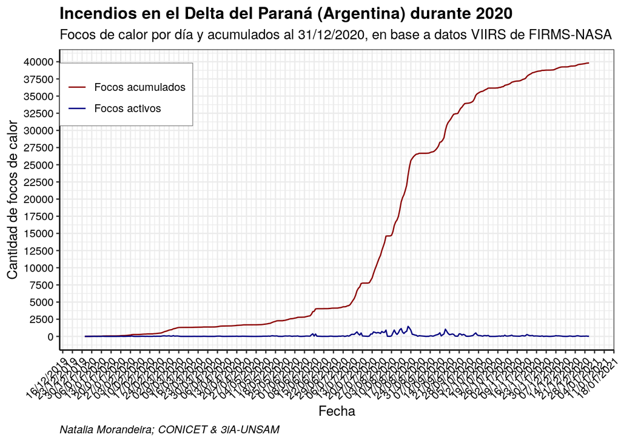

```r
#Spanish
plot_acum <- focos_cum %>%
  pivot_longer(names_to = "focos", values_to = "cantidad", col=cantidad_diaria:acumulado) %>%
  ggplot(aes (x=acq_date, y=cantidad, color=focos)) +
  geom_line() +
  scale_color_manual(values=c("darkred", "navyblue"),  labels = c("Focos acumulados", "Focos activos")) +
  xlab("Fecha") +
  ylab("Cantidad de focos de calor") +
  scale_x_date(date_labels = "%d/%m/%Y", breaks = "week") +
  scale_y_continuous(breaks=seq(from = 0, to = (hotspots_count2020 + 1000), by = 2500)) +
  theme_bw()+
  theme(axis.text.x = element_text(angle=45, hjust=1, color="black"), plot.caption = element_text(hjust = 0, vjust=1, face = "italic"), plot.title = element_text(face = "bold"), legend.position=c(0.12, 0.85), legend.title = element_blank(), axis.line=element_line(color="black"), axis.text.y=element_text(color="black") , legend.background = element_rect(colour ="grey40", size = 0.2)) +
  labs(title="Incendios en el Delta del Paraná (Argentina) durante 2020", subtitle = "Focos de calor por día y acumulados al 31/12/2020, en base a datos VIIRS de FIRMS-NASA", caption = "Natalia Morandeira; CONICET & 3iA-UNSAM")

plot_acum
```

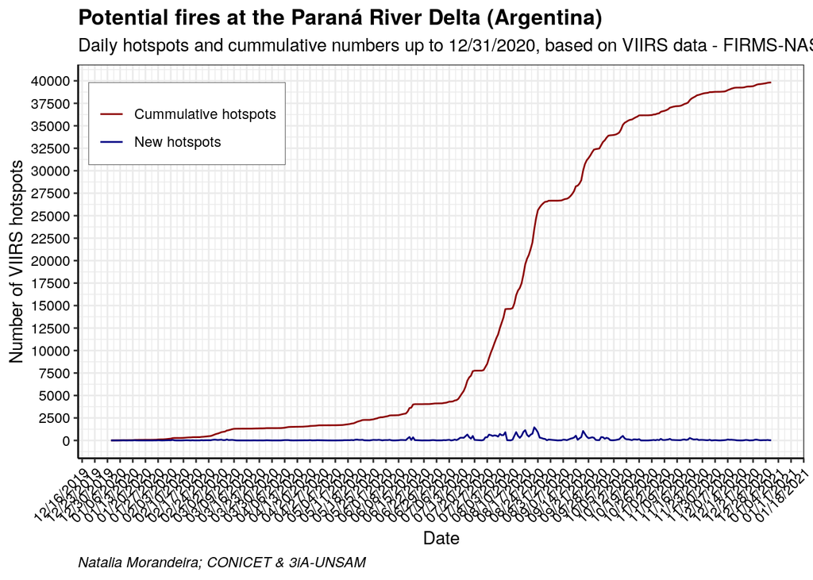

```r
#idem en inglés
plot_cum_eng <- focos_cum %>%
  pivot_longer(names_to = "focos", values_to = "cantidad", col=cantidad_diaria:acumulado) %>%
  ggplot(aes (x=acq_date, y=cantidad, color=focos)) +
  #annotation_custom(rasterGrob(img, width = unit(1,"npc"), height = unit(1,"npc")),
  #                  -Inf, Inf, -Inf, Inf) +
  geom_line() +
  scale_color_manual(values=c("darkred", "navyblue"),  labels = c("Cummulative hotspots", "New hotspots")) +
  xlab("Date") +
  ylab("Number of VIIRS hotspots") +
  scale_x_date(date_labels = "%m/%d/%Y", breaks = "week") +
  scale_y_continuous(breaks=seq(from = 0, to = (hotspots_count2020 + 1000), by = 2500)) +
  theme_bw()+
  theme(axis.text.x = element_text(angle=45, hjust=1, color="black"), plot.caption = element_text(hjust = 0, vjust=1, face = "italic"), plot.title = element_text(face = "bold"), legend.position=c(0.15, 0.85), legend.title = element_blank(), axis.line=element_line(color="black"), axis.text.y=element_text(color="black") , legend.background = element_rect(colour ="grey40", size = 0.2)) +
  labs(title="Potential fires at the Paraná River Delta (Argentina)", subtitle = "Daily hotspots and cummulative numbers up to 12/31/2020, based on VIIRS data - FIRMS-NASA", caption = "Natalia Morandeira; CONICET & 3iA-UNSAM")
plot_cum_eng
```

We may save these plots.

```r
ggsave("output/Focos_acumulados_2020-12-31.png", plot = plot_acum, width = 9, height = 5, dpi = 300)
ggsave("output/Hotspot_cum_2020-12-31.png", plot = plot_cum_eng, width = 9, height = 5, dpi = 300)
```

The next plot summarizes the number of VIIRS hotspots per month.

```r
focos_VIIRS <- hotspots_all
focos_VIIRS <- clean_names(focos_VIIRS)

focos_VIIRS <- focos_VIIRS %>%
  filter(instrument == "VIIRS") %>%
  mutate(cantidad = 1) %>%
  group_by(acq_date) %>%
  summarize(cantidad_diaria = sum(cantidad))
focos_VIIRS2020_mes <- focos_VIIRS %>%
  filter (acq_date > "2020-01-01") %>%
  mutate(mes = format(acq_date, "%Y/%m")) %>%
  group_by(mes) %>%
  summarize(cantidad_mes = sum(cantidad_diaria))
#convertir a fecha
focos_VIIRS2020_mes$mes <- as.Date(paste(focos_VIIRS2020_mes$mes,1,sep="/"),"%Y/%m/%d")
head(focos_VIIRS2020_mes)
```

```
## Simple feature collection with 6 features and 2 fields
## geometry type:  MULTIPOINT
## dimension:      XY
## bbox:           xmin: 5412023 ymin: 6194149 xmax: 5636055 ymax: 6496497
## CRS:            EPSG:5347
## # A tibble: 6 x 3
##   mes        cantidad_mes                                               geometry
##   <date>            <dbl>                                       <MULTIPOINT [m]>
## 1 2020-01-01          137 ((5423082 6441644), (5433803 6494476), (5435337 64887…
## 2 2020-02-01          627 ((5421728 6440928), (5425208 6411022), (5426863 64187…
## 3 2020-03-01          604 ((5419429 6442299), (5421415 6439977), (5421758 64409…
## 4 2020-04-01          317 ((5412704 6439081), (5413885 6436087), (5418441 64302…
## 5 2020-05-01          933 ((5412023 6443372), (5415447 6442151), (5416702 64406…
## 6 2020-06-01         1497 ((5412646 6441587), (5412882 6440502), (5412956 64408…
```

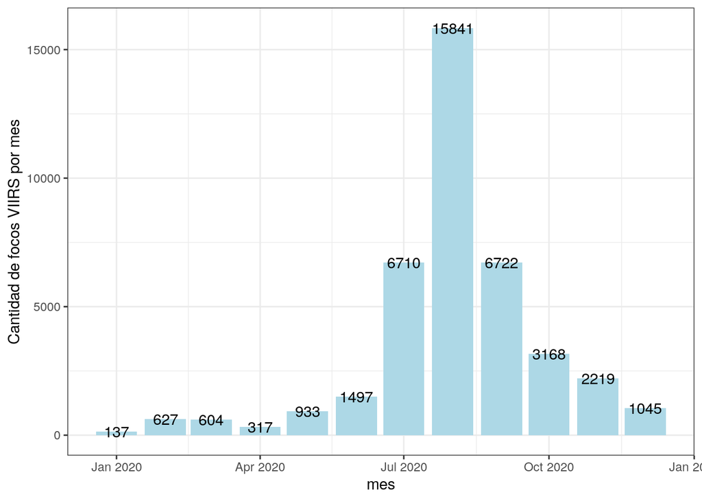

```r
VIIRS2020_mes <- ggplot(focos_VIIRS2020_mes, aes(x=mes, y=cantidad_mes)) +
  geom_col( fill="lightblue") +
  geom_text(aes(label = cantidad_mes), col="black") +
  xlab("mes") +
  ylab("Cantidad de focos VIIRS por mes") +
  theme_bw()
VIIRS2020_mes
```

```r
VIIRSagosto <- (focos_VIIRS2020_mes$cantidad_mes)[8]

ggsave("output/Focos_VIIRS2020_mensual.png", plot = VIIRS2020_mes, width = 8, height = 5, dpi = 300)
```

The month with the highest number of hotspots is August, with **1.584110^{4}** hotspots (**39.8%** % of the total hotspots up to **2020-12-31**).

While VIIRS data (resolution: 375 m) is available from 2012, MODIS data is available from 2001. However, MODIS resolution is 1 km, so fewer hotspots are reported and each hotspot corresponds to a greater area.

```r
focos_MODIS <- hotspots_all

focos_MODIS <- clean_names(focos_MODIS)
colnames(focos_MODIS)
```

```
##  [1] "latitude"   "longitude"  "brightness" "scan"       "track"
##  [6] "acq_date"   "acq_time"   "satellite"  "instrument" "version"
## [11] "bright_t31" "frp"        "daynight"   "geometry"
```

```r
focos_MODIS <- focos_MODIS %>%
  filter(instrument == "MODIS") %>%
  mutate(cantidad = 1) %>%
  group_by(acq_date) %>%
  summarize(cantidad_diaria = sum(cantidad))
head(focos_MODIS)
```

```
## Simple feature collection with 6 features and 2 fields
## geometry type:  GEOMETRY
## dimension:      XY
## bbox:           xmin: 5464067 ymin: 6235273 xmax: 5640738 ymax: 6359511
## CRS:            EPSG:5347
## # A tibble: 6 x 3
##   acq_date   cantidad_diaria                                            geometry
##   <date>               <dbl>                                      <GEOMETRY [m]>
## 1 2000-11-16               1                             POINT (5640738 6255500)
## 2 2000-11-18               4 MULTIPOINT ((5464067 6359511), (5473032 6321065), …
## 3 2001-01-12               2   MULTIPOINT ((5488228 6331211), (5489226 6331034))
## 4 2001-01-16               2   MULTIPOINT ((5562212 6266253), (5563775 6265877))
## 5 2001-01-21               1                             POINT (5612500 6235273)
## 6 2001-02-06               2   MULTIPOINT ((5567295 6261782), (5567501 6260715))
```

Now we compute and plot the number of MODIS hotspots per year.

```r
#calculo de focos por anio
focos_MODIS_anio <- focos_MODIS %>%
  mutate(anio = format(acq_date, "%Y")) %>%
  group_by(anio) %>%
  summarize(cantidad_anio = sum(cantidad_diaria))
glimpse(focos_MODIS_anio)
```

```
## Rows: 21
## Columns: 3
## $ anio          <chr> "2000", "2001", "2002", "2003", "2004", "2005", "2006",…
## $ cantidad_anio <dbl> 5, 132, 559, 1023, 6687, 1410, 6065, 267, 13780, 1044, …
## $ geometry      <MULTIPOINT [m]> MULTIPOINT ((5464067 635951..., MULTIPOINT (…
```

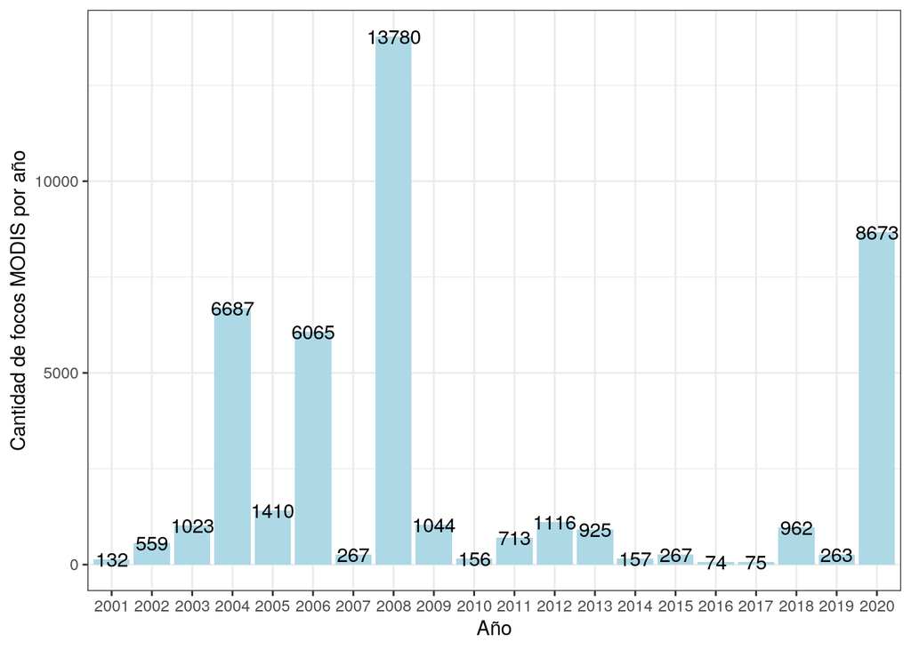

```r
MODIS_year <- ggplot(subset(focos_MODIS_anio, focos_MODIS_anio$anio!="2000"), aes(x=anio, y=cantidad_anio)) +
  geom_col( fill="lightblue") +
  geom_text(aes(label = cantidad_anio), col="black") +
  xlab("Año") +
  ylab("Cantidad de focos MODIS por año") +
  theme_bw()
MODIS_year
```

```r
ggsave("output/MODIS_2001-2020.png", plot = MODIS_year, width = 9, height = 5, dpi = 300)

MODIS_2020 <- as.numeric(as.list(subset(focos_MODIS_anio, focos_MODIS_anio$anio ==2020))[2])
MODIS_2008 <-  as.numeric(as.list(subset(focos_MODIS_anio, focos_MODIS_anio$anio ==2008))[2])
```

The cumulative number of MODIS hotspots during 2020 is **8673** up to **2020-12-31**, which is **62.9%** of the MODIS hotspots recorded during 2008.

Some plots summarizing the historical hotspots from MODIS data. Daily and monthly plots.

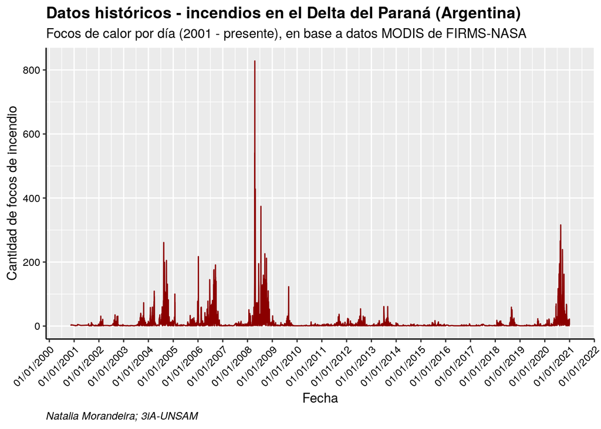

```r
#diario
MODIS_diario <- focos_MODIS %>%
  ggplot(aes (x=acq_date, y=cantidad_diaria)) +
  geom_line(color="darkred") +
  xlab("Fecha") +
  ylab("Cantidad de focos de incendio") +
  scale_x_date(date_labels = "%d/%m/%Y", breaks = "year") +
  theme(axis.text.x = element_text(angle=45, hjust=1, color="black"), plot.caption = element_text(hjust = 0, vjust=1, face = "italic"), plot.title = element_text(face = "bold"), legend.position=c(0.12, 0.85), legend.title = element_blank(), axis.line=element_line(color="black"), axis.text.y=element_text(color="black")) +
  labs(title="Datos históricos - incendios en el Delta del Paraná (Argentina)", subtitle = "Focos de calor por día (2001 - presente), en base a datos MODIS de FIRMS-NASA", caption = "Natalia Morandeira; 3iA-UNSAM")

MODIS_diario
```

```r
#ggsave("Focos_historicos_diarios.png", plot = p3, width = 8, height = 5, dpi = 300)
```

```r
#agrupar dias en meses
focos_MODIS_mes <- focos_MODIS %>%
  mutate(mes = format(acq_date, "%Y/%m")) %>%
  group_by(mes) %>%
  summarize(cantidad_mes = sum(cantidad_diaria))
#convertir a fecha
focos_MODIS_mes$mes <- as.Date(paste(focos_MODIS_mes$mes,1,sep="/"),"%Y/%m/%d")
head(focos_MODIS_mes)
```

```
## Simple feature collection with 6 features and 2 fields
## geometry type:  MULTIPOINT
## dimension:      XY
## bbox:           xmin: 5431559 ymin: 6220549 xmax: 5640738 ymax: 6479612
## CRS:            EPSG:5347
## # A tibble: 6 x 3
##   mes        cantidad_mes                                               geometry
##   <date>            <dbl>                                       <MULTIPOINT [m]>
## 1 2000-11-01            5 ((5464067 6359511), (5473032 6321065), (5569140 62556…
## 2 2001-01-01            5 ((5488228 6331211), (5489226 6331034), (5562212 62662…
## 3 2001-02-01            9 ((5567295 6261782), (5567501 6260715), (5585151 62429…
## 4 2001-04-01            2                 ((5596628 6220737), (5597631 6220549))
## 5 2001-07-01            3 ((5636164 6241319), (5637364 6241136), (5637537 62422…
## 6 2001-08-01           16 ((5431559 6479612), (5441331 6436601), (5441903 64372…
```

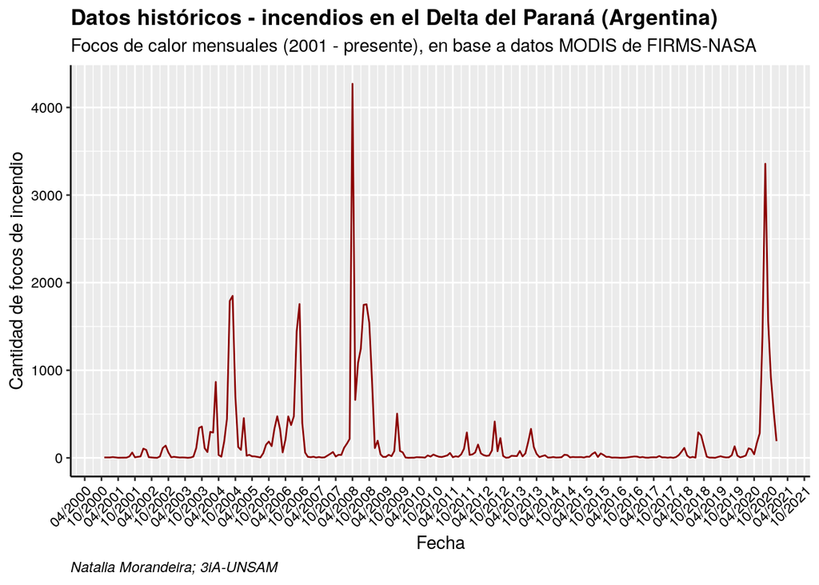

```r
MODIS_mes <-  focos_MODIS_mes %>%
  ggplot(aes (x=mes, y=cantidad_mes)) +
  geom_line(col="darkred") +
  scale_color_manual(values=c("red", "blue"),  labels = c("Focos acumulados", "Nuevos focos")) +
  xlab("Fecha") +
  ylab("Cantidad de focos de incendio") +
  scale_x_date(date_labels = "%m/%Y", breaks = "6 months") +
  theme(axis.text.x = element_text(angle=45, hjust=1, color="black"), plot.caption = element_text(hjust = 0, vjust=1, face = "italic"), plot.title = element_text(face = "bold"), legend.position=c(0.12, 0.85), legend.title = element_blank(), axis.line=element_line(color="black"), axis.text.y=element_text(color="black")) +
  labs(title="Datos históricos - incendios en el Delta del Paraná (Argentina)", subtitle = "Focos de calor mensuales (2001 - presente), en base a datos MODIS de FIRMS-NASA", caption = "Natalia Morandeira; 3iA-UNSAM")

MODIS_mes
```

```r
#ggsave("Focos_historicos_mensual.png", plot = p4, width = 8, height = 5, dpi = 300)
```

Now we can compare VIIRS and MODIS records, from 2012.

```r
focos_VIIRS <- hotspots_all
focos_VIIRS <- clean_names(focos_VIIRS)

focos_VIIRS <- focos_VIIRS %>%
  filter(instrument == "VIIRS") %>%
  mutate(cantidad = 1) %>%
  group_by(acq_date) %>%
  summarize(cantidad_diaria = sum(cantidad))
#calculo de focos por anio
focos_VIIRS_anio <- focos_VIIRS %>%
  mutate(anio = format(acq_date, "%Y")) %>%
  group_by(anio) %>%
  summarize(cantidad_anio = sum(cantidad_diaria))
glimpse(focos_VIIRS_anio)
```

```
## Rows: 9
## Columns: 3
## $ anio          <chr> "2012", "2013", "2014", "2015", "2016", "2017", "2018",…
## $ cantidad_anio <dbl> 4262, 4072, 1032, 1468, 645, 725, 5080, 1530, 39821
## $ geometry      <MULTIPOINT [m]> MULTIPOINT ((5412516 645754..., MULTIPOINT (…
```

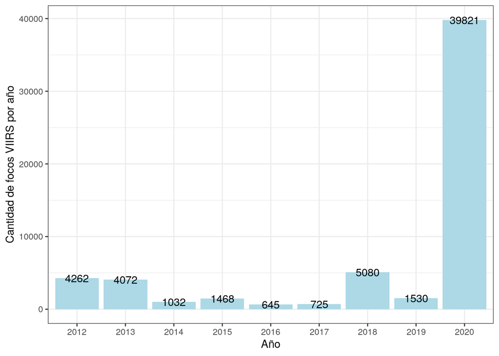

```r
#write.csv(x = focos_VIIRS_anio, file = "focos_anuales_VIIRS.csv")


VIIRS_anio <- ggplot(subset(focos_VIIRS_anio, focos_VIIRS_anio$anio!="2000"), aes(x=anio, y=cantidad_anio)) +
  geom_col( fill="lightblue") +
  geom_text(aes(label = cantidad_anio), col="black") +
  xlab("Año") +
  ylab("Cantidad de focos VIIRS por año") +
  theme_bw()
VIIRS_anio
```

```r
ggsave("output/VIIRS_2012-2020.png", plot = VIIRS_anio, width = 9, height = 5, dpi = 300)
```

```r
#preparo label del eje X
break.fecha <- c(seq(from = as.Date("2001-01-01"), to = as.Date("2020-11-01"), by = "6 months"), as.Date("2021-01-01"))

#agrupar dias en meses
focos_VIIRS_mes <- focos_VIIRS %>%
  mutate(mes = format(acq_date, "%Y/%m")) %>%
  group_by(mes) %>%
  summarize(cantidad_mes = sum(cantidad_diaria))
#convertir a fecha
focos_VIIRS_mes$mes <- as.Date(paste(focos_VIIRS_mes$mes,1,sep="/"),"%Y/%m/%d")
head(focos_VIIRS_mes)
```

```
## Simple feature collection with 6 features and 2 fields
## geometry type:  MULTIPOINT
## dimension:      XY
## bbox:           xmin: 5412965 ymin: 6197827 xmax: 5638964 ymax: 6495169
## CRS:            EPSG:5347
## # A tibble: 6 x 3
##   mes        cantidad_mes                                               geometry
##   <date>            <dbl>                                       <MULTIPOINT [m]>
## 1 2012-01-01          291 ((5430382 6463107), (5432119 6420590), (5432213 64164…
## 2 2012-02-01          211 ((5446945 6490081), (5473087 6321123), (5473545 63211…
## 3 2012-03-01          143 ((5446692 6490207), (5463869 6352244), (5466056 63507…
## 4 2012-04-01          149 ((5473161 6321233), (5473684 6320912), (5473690 63208…
## 5 2012-05-01          111 ((5464172 6350959), (5464470 6351883), (5464951 63519…
## 6 2012-06-01          276 ((5412965 6442563), (5413932 6464492), (5413993 64640…
```

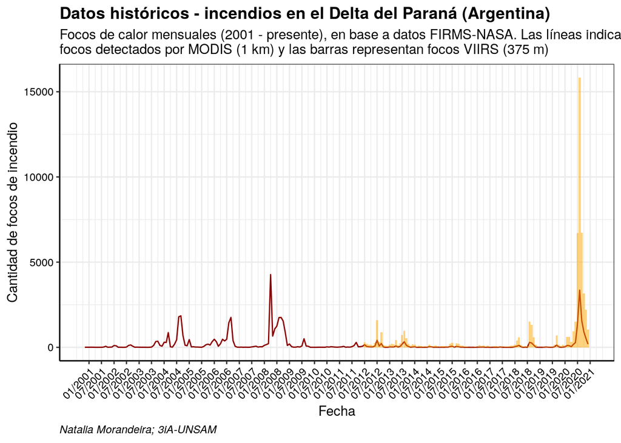

```r
MODIS_VIIRS_plot <-  ggplot(data = focos_MODIS_mes, aes (x=mes, y=cantidad_mes)) +
  geom_line(col="darkred") +
  xlab("Fecha") +
  ylab("Cantidad de focos de incendio") +
  scale_x_date(date_labels = "%m/%Y", breaks = break.fecha) +
  theme_bw() +
  theme(axis.text.x = element_text(angle=45, hjust=1, color="black"), plot.caption = element_text(hjust = 0, vjust=1, face = "italic"), plot.title = element_text(face = "bold"), legend.position=c(0.12, 0.85), legend.title = element_blank(), axis.line=element_line(color="black"), axis.text.y=element_text(color="black")) +
  labs(title="Datos históricos - incendios en el Delta del Paraná (Argentina)", subtitle = "Focos de calor mensuales (2001 - presente), en base a datos FIRMS-NASA. Las líneas indican \nfocos detectados por MODIS (1 km) y las barras representan focos VIIRS (375 m)", caption = "Natalia Morandeira; 3iA-UNSAM")

MODIS_VIIRS_plot<- MODIS_VIIRS_plot + geom_col(data= focos_VIIRS_mes, aes (x=mes, y=cantidad_mes, group=1),  fill="orange", alpha=0.5, width = 30)

MODIS_VIIRS_plot
```

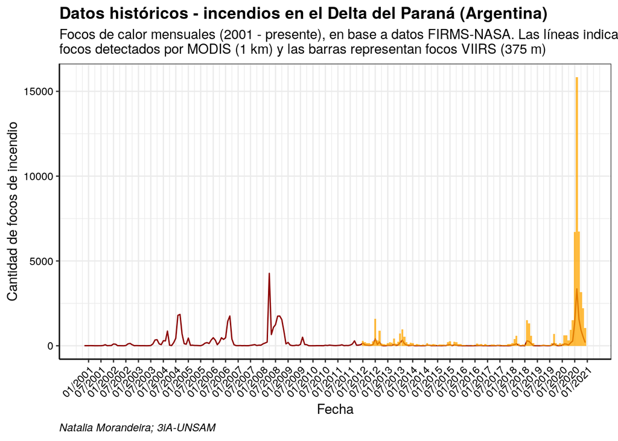

```r
MODIS_VIIRS_plot_eng <-  ggplot(data = focos_MODIS_mes, aes (x=mes, y=cantidad_mes)) +
  geom_line(col="darkred") +
  xlab("Date") +
  ylab("Number of hotspots") +
  scale_x_date(date_labels = "%m/%Y", breaks = break.fecha) +
  theme_bw() +
  theme(axis.text.x = element_text(angle=45, hjust=1, color="black"), plot.caption = element_text(hjust = 0, vjust=1, face = "italic"), plot.title = element_text(face = "bold"), legend.position=c(0.12, 0.85), legend.title = element_blank(), axis.line=element_line(color="black"), axis.text.y=element_text(color="black")) +
  labs(title="Historical data - Potential fires in the Paraná River Delta (Argentina)", subtitle = "Monthly number of hotspots (2001 - present), based on FIRMS-NASA data. \nLines indicate MODIS hotspots (1 km) and bars indicate VIIRS hotspots (375 m)", caption = "Patricia Kandus, Natalia Morandeira and Priscilla Minotti; 3iA-UNSAM")

MODIS_VIIRS_plot_eng <- MODIS_VIIRS_plot + geom_col(data= focos_VIIRS_mes, aes (x=mes, y=cantidad_mes, group=1),  fill="orange", alpha=0.5, width = 30)

MODIS_VIIRS_plot_eng
```

We may save these plots.

```r
ggsave("output/Focos_historicos_ambossensores.png", plot = MODIS_VIIRS_plot, width = 9, height = 5, dpi = 300)
ggsave("output/Focos_historicos_ambossensores_english.png", plot = MODIS_VIIRS_plot_eng, width = 9, height = 5, dpi = 300)
```